# Lab 10 - Using R Markdown

Bree Bang-Jensen

1/8/2019

## R Markdown Basics

We will now be doing all of our labs and homework in R Markdown, rather than in a basic .R script file. This is also how you will write the code for your own analyses for your projects. Welcome to the future!

Go ahead and open a new R Markdown file – it’s in the pull down menu where you’ve previously been selecting a new R Script file.

The basic point of R Markdown is to discuss code, write code, show results easily, and do all of this in one place. Let’s break that down.

### Discuss Your Code

This is as simple as typing in a Word document. To structure your discussion, you can add headers and subheaders (as above), *italics*, and **bold**. You can also add block quotes.

> Here’s a thing I’d like to emphasize. Maybe a formula. Or an important fact.

We can also add horizontal lines. There are other formatting options, and the R Markdown cheat sheet is a handy way to keep them all straight (I’ve also added this PDF to the lab blog for this week: (https://www.rstudio.com/wp-content/uploads/2015/02/rmarkdown-cheatsheet.pdf)

### Write Code & Print Results

You can add chunks of code to your R Markdown document using the **Insert** button, and selecting R. This is what a basic piece of embedded R code looks like:

```r
x <- 10
x
```

```
## [1] 10
```

```r
print("sup")
```

```
## [1] "sup"
```

Your code should all go on lines between the triple accent marks.

There are some important options available to you for each code chunk:

- **eval** (default is TRUE): Whether to evaluate the code and include its results
- **echo** (default is TRUE): Whether to display code along with its results
- **warning** (default is TRUE): Whether to display warnings
- **error** (default is FALSE): Whether to display errors
- **message** (default is TRUE): Whether to display messages
- **tidy** (default is FALSE): Whether to reformat code in a tidy way when displaying it
- **include**(default is TRUE): Whether to include all output (code, results, messages, etc.)

Here’s a demonstration of where these options go in your code chunk: the header.

```r
y <- 20
y
```

```
## [1] 20
```

In general, you do not want to display errors, warnings, or messages in your R Markdown document, so you should set those options to FALSE as needed.

## How Not to Use R Markdown

Let’s look at an embedded code chunk using a variant of code from an old homework. Here’s a good example of how to make a messy and sad R Markdown homework.

So this is problem 4:

```r
library("dplyr")
```

```r
library("gapminder")
library("ggplot2")

gdp_table <- gapminder %>%
  group_by(year, continent) %>%
  summarize(av_gdp_per_cap = mean(gdpPercap))

gdp_table
```

```
## # A tibble: 60 x 3
## # Groups:   year [12]
##     year continent av_gdp_per_cap
##    <int> <fct>              <dbl>
##  1  1952 Africa             1253.
##  2  1952 Americas           4079.
##  3  1952 Asia               5195.
##  4  1952 Europe             5661.
##  5  1952 Oceania           10298.
##  6  1957 Africa             1385.
##  7  1957 Americas           4616.
##  8  1957 Asia               5788.
##  9  1957 Europe             6963.
## 10  1957 Oceania           11599.
## # … with 50 more rows
```

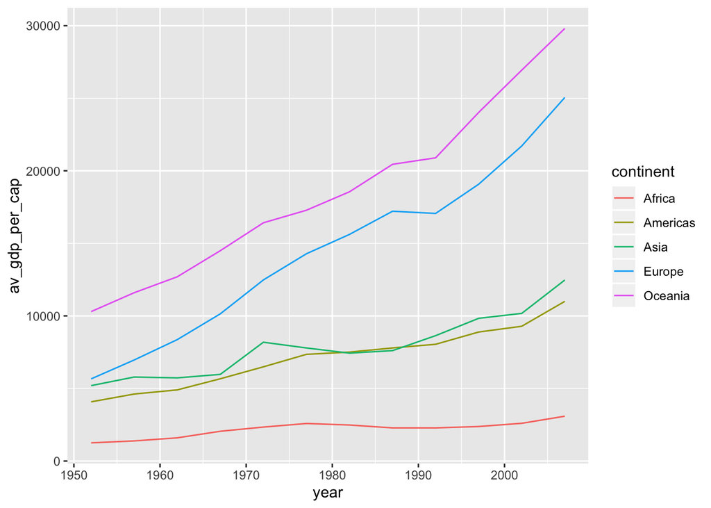

```r
ggplot(gdp_table, aes(x = year, y = av_gdp_per_cap, color = continent)) + geom_line()
```

## A Better Way

### Problem 4

First, I will load the required packages: dplyr, ggplot2, and the gapminder data set.

```r
library("dplyr")
library("gapminder")
library("ggplot2")
```

Then, I will group the gapminder data by year, and then by continent, and then use the summarize function on each “year-continent” group in order to calculate the mean.

```r
gdp_table <- gapminder %>%
  group_by(year, continent) %>%
  summarize(av_gdp_per_cap = mean(gdpPercap))
```

Here is the head of the resulting table of average GDP by continent by year.

```
## # A tibble: 6 x 3
## # Groups:   year [2]
##    year continent av_gdp_per_cap
##   <int> <fct>              <dbl>
## 1  1952 Africa             1253.
## 2  1952 Americas           4079.
## 3  1952 Asia               5195.
## 4  1952 Europe             5661.
## 5  1952 Oceania           10298.
## 6  1957 Africa             1385.
```

This table is not the easiest way to conceptualize the data, though: a graph showing change over time in average GDP for each continent is much easier to understand.

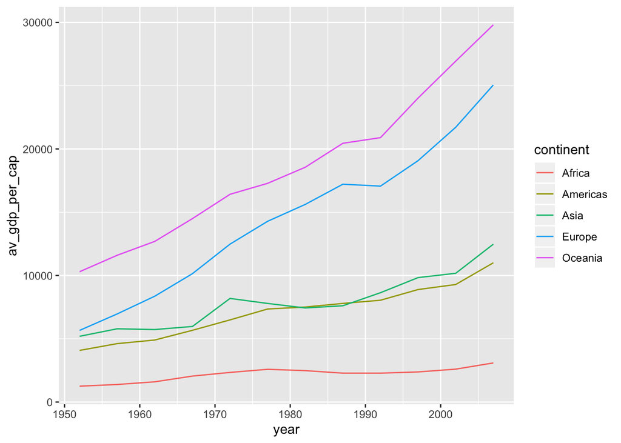

```r
ggplot(gdp_table, aes(x = year, y = av_gdp_per_cap, color = continent)) + geom_line()
```

### Couple Additional Notes (courtesy of Karl Broman)

Here’s where the name would go:

```r
x
```

```
## [1] 10
```

**Setting global options:** You may be inclined to use largely the same set of chunk options throughout a document. But it would be a pain to retype those options in every chunk. Thus, you want to set some global chunk options at the top of your document.

It could look something like this:

```r
knitr::opts_chunk$set(echo = FALSE, warning = FALSE, message = FALSE)
```

Because the global chunk options become the defaults for the rest of the document, you have to specify a different option (within that chunk) if you want a particular chunk to have a different behavior.

**Using In-Line Code**: When discussing the results of a given calculation in your written commentary, we want to be referencing R calculations, not simply typing numbers that appeared in the console.

That’s the point of using in-line code. You’d write something like “There are 1704 observations in the data.” Another example: “The estimated correlation between x and y was 0.2273181.”